# IMDB Exploratory Analysis Tutorial

[figure not shown]

Jason He 113590306 Shihang Zeng 115048621

IMDb is the one of the biggest movies rating website in the world, we would like to analyze the correlation between rating score and all the other elements, and find out what element can affect the rating score of a movie.

Also we want to build a model to predict the rating scroe of a movie based on the data we have on IMDb, so that we can understand how to make a movie that people think is good, and what kind of movie the investor and movie maker should make.

One of the application we can use for this project is that we can build a better movie suggestion machine learning algorithm for companies like Nextflix.

# Getting Started

Before getting started, you will need to install the various libraries that we will use. We will be using many commonly-used libraries such as Pandas and Numpy, as well as Matplotlib and Ggplot for plotting data and Statsmodels for linear regression models and features. All of these canbe installed using pip:

% pip install

This tutorial will use data from Imdb pulled from Kaggle.com. The database is accessed through URL in this tutorial, but the database can also, be The database can also be downloaded into the folder of this notebook to be accessed locally on your machine through https://www.kaggle.com/orgesleka/imdbmovies.

```python
%matplotlib inline

import pandas as pd
import numpy as np
import matplotlib.pyplot as plt
import statsmodels.formula.api as smf

# Change to "data = pd.read_csv('imdb.csv', escapechar='\\')" for local access after download.
data = pd.read_csv('https://raw.githubusercontent.com/orgesleka/filmempfehlung/master/imdb/imdb.csv', escapechar='\\')
data.head()
```

|  | fn | tid | title | wordsInTitle | url | imdbRating | ratingCount | duration | year | type | ... | News | RealityTV | Romance | SciFi | Short | Sport | TalkShow | Thriller | War | Western |
| --- | --- | --- | --- | --- | --- | --- | --- | --- | --- | --- | --- | --- | --- | --- | --- | --- | --- | --- | --- | --- | --- |
| 0 | titles01/tt0012349 | tt0012349 | Der Vagabund und das Kind (1921) | der vagabund und das kind | http://www.imdb.com/title/tt0012349/ | 8.4 | 40550.0 | 3240.0 | 1921.0 | video.movie | ... | 0 | 0 | 0 | 0 | 0 | 0 | 0 | 0 | 0 | 0 |
| 1 | titles01/tt0015864 | tt0015864 | Goldrausch (1925) | goldrausch | http://www.imdb.com/title/tt0015864/ | 8.3 | 45319.0 | 5700.0 | 1925.0 | video.movie | ... | 0 | 0 | 0 | 0 | 0 | 0 | 0 | 0 | 0 | 0 |
| 2 | titles01/tt0017136 | tt0017136 | Metropolis (1927) | metropolis | http://www.imdb.com/title/tt0017136/ | 8.4 | 81007.0 | 9180.0 | 1927.0 | video.movie | ... | 0 | 0 | 0 | 1 | 0 | 0 | 0 | 0 | 0 | 0 |
| 3 | titles01/tt0017925 | tt0017925 | Der General (1926) | der general | http://www.imdb.com/title/tt0017925/ | 8.3 | 37521.0 | 6420.0 | 1926.0 | video.movie | ... | 0 | 0 | 0 | 0 | 0 | 0 | 0 | 0 | 0 | 0 |
| 4 | titles01/tt0021749 | tt0021749 | Lichter der Großstadt (1931) | lichter der gro stadt | http://www.imdb.com/title/tt0021749/ | 8.7 | 70057.0 | 5220.0 | 1931.0 | video.movie | ... | 0 | 0 | 1 | 0 | 0 | 0 | 0 | 0 | 0 | 0 |

5 rows × 44 columns

Above what the data from "imdb.csv" looks like. The file is imported as a Pandas DataFrame object. For this tutorial, we are only interested in data about movies, so entries without the 'type' of 'video.movie' will not be needed. Also, many of the columns for the Imdb data will not be needed in our analysis, so they will be dropped before we proceed with this tutorial. Shown below is the DataFrame with unnecessary data omitted.

```python
data = data.loc[data['type'] == 'video.movie']
columns = ['fn', 'tid', 'wordsInTitle', 'url', 'type', 'nrOfWins', 'nrOfNominations', 'nrOfPhotos', 'nrOfNewsArticles']
imdb = data.drop(columns, axis=1)
imdb
```

|  | title | imdbRating | ratingCount | duration | year | nrOfUserReviews | nrOfGenre | Action | Adult | Adventure | ... | News | RealityTV | Romance | SciFi | Short | Sport | TalkShow | Thriller | War | Western |
| --- | --- | --- | --- | --- | --- | --- | --- | --- | --- | --- | --- | --- | --- | --- | --- | --- | --- | --- | --- | --- | --- |
| 0 | Der Vagabund und das Kind (1921) | 8.4 | 40550.0 | 3240.0 | 1921.0 | 85 | 3 | 0 | 0 | 0 | ... | 0 | 0 | 0 | 0 | 0 | 0 | 0 | 0 | 0 | 0 |
| 1 | Goldrausch (1925) | 8.3 | 45319.0 | 5700.0 | 1925.0 | 122 | 3 | 0 | 0 | 1 | ... | 0 | 0 | 0 | 0 | 0 | 0 | 0 | 0 | 0 | 0 |
| 2 | Metropolis (1927) | 8.4 | 81007.0 | 9180.0 | 1927.0 | 376 | 2 | 0 | 0 | 0 | ... | 0 | 0 | 0 | 1 | 0 | 0 | 0 | 0 | 0 | 0 |
| 3 | Der General (1926) | 8.3 | 37521.0 | 6420.0 | 1926.0 | 219 | 3 | 1 | 0 | 1 | ... | 0 | 0 | 0 | 0 | 0 | 0 | 0 | 0 | 0 | 0 |
| 4 | Lichter der Großstadt (1931) | 8.7 | 70057.0 | 5220.0 | 1931.0 | 186 | 3 | 0 | 0 | 0 | ... | 0 | 0 | 1 | 0 | 0 | 0 | 0 | 0 | 0 | 0 |
| 5 | M (1931) | 8.5 | 73726.0 | 7020.0 | 1931.0 | 254 | 3 | 0 | 0 | 0 | ... | 0 | 0 | 0 | 0 | 0 | 0 | 0 | 1 | 0 | 0 |
| 6 | Es geschah in einer Nacht (1934) | 8.3 | 46503.0 | 6300.0 | 1934.0 | 211 | 2 | 0 | 0 | 0 | ... | 0 | 0 | 1 | 0 | 0 | 0 | 0 | 0 | 0 | 0 |
| 7 | Moderne Zeiten (1936) | 8.6 | 90847.0 | 5220.0 | 1936.0 | 180 | 2 | 0 | 0 | 0 | ... | 0 | 0 | 0 | 0 | 0 | 0 | 0 | 0 | 0 | 0 |
| 8 | Vom Winde verweht (1939) | 8.2 | 160414.0 | 14280.0 | 1939.0 | 653 | 3 | 0 | 0 | 0 | ... | 0 | 0 | 1 | 0 | 0 | 0 | 0 | 0 | 1 | 0 |
| 9 | Mr. Smith geht nach Washington (1939) | 8.4 | 58169.0 | 7740.0 | 1939.0 | 226 | 1 | 0 | 0 | 0 | ... | 0 | 0 | 0 | 0 | 0 | 0 | 0 | 0 | 0 | 0 |
| 10 | Der Zauberer von Oz (1939) | 8.1 | 209506.0 | 6120.0 | 1939.0 | 477 | 3 | 0 | 0 | 1 | ... | 0 | 0 | 0 | 0 | 0 | 0 | 0 | 0 | 0 | 0 |
| 11 | Früchte des Zorns (1940) | 8.2 | 45737.0 | 7740.0 | 1940.0 | 257 | 1 | 0 | 0 | 0 | ... | 0 | 0 | 0 | 0 | 0 | 0 | 0 | 0 | 0 | 0 |
| 12 | Der große Diktator (1940) | 8.5 | 87969.0 | 7500.0 | 1940.0 | 173 | 3 | 0 | 0 | 0 | ... | 0 | 0 | 0 | 0 | 0 | 0 | 0 | 0 | 1 | 0 |
| 13 | Rebecca (1940) | 8.3 | 65670.0 | 7800.0 | 1940.0 | 241 | 3 | 0 | 0 | 0 | ... | 0 | 0 | 0 | 0 | 0 | 0 | 0 | 1 | 0 | 0 |
| 14 | Citizen Kane (1941) | 8.5 | 228617.0 | 7140.0 | 1941.0 | 1101 | 2 | 0 | 0 | 0 | ... | 0 | 0 | 0 | 0 | 0 | 0 | 0 | 0 | 0 | 0 |
| 15 | Die Spur des Falken (1941) | 8.2 | 86012.0 | 6000.0 | 1941.0 | 294 | 3 | 0 | 0 | 0 | ... | 0 | 0 | 0 | 0 | 0 | 0 | 0 | 0 | 0 | 0 |
| 16 | Casablanca (1942) | 8.6 | 296802.0 | 6120.0 | 1942.0 | 960 | 3 | 0 | 0 | 0 | ... | 0 | 0 | 1 | 0 | 0 | 0 | 0 | 0 | 1 | 0 |
| 17 | Frau ohne Gewissen (1944) | 8.5 | 71266.0 | 6420.0 | 1944.0 | 260 | 3 | 0 | 0 | 0 | ... | 0 | 0 | 0 | 0 | 0 | 0 | 0 | 0 | 0 | 0 |
| 18 | Die besten Jahre unseres Lebens (1946) | 8.3 | 30002.0 | 10320.0 | 1946.0 | 218 | 3 | 0 | 0 | 0 | ... | 0 | 0 | 1 | 0 | 0 | 0 | 0 | 0 | 1 | 0 |
| 19 | Tote schlafen fest (1946) | 8.1 | 50020.0 | 6840.0 | 1946.0 | 215 | 3 | 0 | 0 | 0 | ... | 0 | 0 | 0 | 0 | 0 | 0 | 0 | 0 | 0 | 0 |
| 20 | It's a Wonderful Life (1946) | 8.7 | 197764.0 | 7800.0 | 1946.0 | 626 | 3 | 0 | 0 | 0 | ... | 0 | 0 | 0 | 0 | 0 | 0 | 0 | 0 | 0 | 0 |
| 21 | Berüchtigt (1946) | 8.2 | 56306.0 | 6060.0 | 1946.0 | 260 | 3 | 0 | 0 | 0 | ... | 0 | 0 | 1 | 0 | 0 | 0 | 0 | 0 | 0 | 0 |
| 22 | Fahrraddiebe (1948) | 8.4 | 63797.0 | 5280.0 | 1948.0 | 202 | 1 | 0 | 0 | 0 | ... | 0 | 0 | 0 | 0 | 0 | 0 | 0 | 0 | 0 | 0 |
| 23 | Cocktail für eine Leiche (1948) | 8.1 | 72370.0 | 4800.0 | 1948.0 | 283 | 3 | 0 | 0 | 0 | ... | 0 | 0 | 0 | 0 | 0 | 0 | 0 | 1 | 0 | 0 |
| 24 | Der Schatz der Sierra Madre (1948) | 8.4 | 59298.0 | 7560.0 | 1948.0 | 190 | 3 | 1 | 0 | 1 | ... | 0 | 0 | 0 | 0 | 0 | 0 | 0 | 0 | 0 | 0 |
| 25 | Der dritte Mann (1949) | 8.4 | 85964.0 | 6240.0 | 1949.0 | 364 | 3 | 0 | 0 | 0 | ... | 0 | 0 | 0 | 0 | 0 | 0 | 0 | 1 | 0 | 0 |
| 26 | Alles über Eva (1950) | 8.4 | 61738.0 | 8280.0 | 1950.0 | 276 | 1 | 0 | 0 | 0 | ... | 0 | 0 | 0 | 0 | 0 | 0 | 0 | 0 | 0 | 0 |
| 27 | Rashomon (1950) | 8.4 | 74219.0 | 5280.0 | 1950.0 | 238 | 2 | 0 | 0 | 0 | ... | 0 | 0 | 0 | 0 | 0 | 0 | 0 | 0 | 0 | 0 |
| 28 | Boulevard der Dämmerung (1950) | 8.6 | 102072.0 | 6600.0 | 1950.0 | 394 | 2 | 0 | 0 | 0 | ... | 0 | 0 | 0 | 0 | 0 | 0 | 0 | 0 | 0 | 0 |
| 29 | Der Fremde im Zug (1951) | 8.1 | 69387.0 | 5520.0 | 1951.0 | 245 | 3 | 0 | 0 | 0 | ... | 0 | 0 | 0 | 0 | 0 | 0 | 0 | 1 | 0 | 0 |
| ... | ... | ... | ... | ... | ... | ... | ... | ... | ... | ... | ... | ... | ... | ... | ... | ... | ... | ... | ... | ... | ... |
| 14609 | Daddy ohne Plan (2007) | 6.2 | 34283.0 | 6600.0 | 2007.0 | 80 | 3 | 0 | 0 | 0 | ... | 0 | 0 | 0 | 0 | 0 | 1 | 0 | 0 | 0 | 0 |
| 14610 | Gin-iro no kami no Agito (2006) | 6.5 | 2770.0 | 5700.0 | 2006.0 | 19 | 3 | 0 | 0 | 0 | ... | 0 | 0 | 1 | 0 | 0 | 0 | 0 | 0 | 0 | 0 |
| 14611 | Jackass Nummer zwei (2006) | 7.2 | 48137.0 | 5520.0 | 2006.0 | 190 | 3 | 1 | 0 | 0 | ... | 0 | 0 | 0 | 0 | 0 | 0 | 0 | 0 | 0 | 0 |
| 14612 | Die Frau im Hermelin (1948) | 5.9 | 399.0 | 5340.0 | 1948.0 | 14 | 3 | 0 | 0 | 0 | ... | 0 | 0 | 0 | 0 | 0 | 0 | 0 | 0 | 0 | 0 |
| 14614 | Hilfe, mein Tagebuch ist ein Bestseller (TV Mo... | 5.6 | 3091.0 | 5040.0 | 2006.0 | 58 | 3 | 0 | 0 | 0 | ... | 0 | 0 | 0 | 0 | 0 | 0 | 0 | 0 | 0 | 0 |
| 14615 | Movie Music Mania (TV Movie 2005) | 5.4 | 8.0 | 2880.0 | 2005.0 | 0 | 2 | 0 | 0 | 0 | ... | 0 | 0 | 0 | 0 | 0 | 0 | 0 | 0 | 0 | 0 |
| 14616 | Gangster (2006) | 7.1 | 2424.0 | 7380.0 | 2006.0 | 40 | 3 | 0 | 0 | 0 | ... | 0 | 0 | 0 | 0 | 0 | 0 | 0 | 0 | 0 | 0 |
| 14617 | Budd Boetticher: An American Original (Video 2... | 6.4 | 43.0 | 3060.0 | 2005.0 | 0 | 1 | 0 | 0 | 0 | ... | 0 | 0 | 0 | 0 | 0 | 0 | 0 | 0 | 0 | 0 |
| 14620 | Die Gräfin (2009) | 6.3 | 5148.0 | 5880.0 | 2009.0 | 25 | 3 | 0 | 0 | 0 | ... | 0 | 0 | 0 | 0 | 0 | 0 | 0 | 0 | 0 | 0 |
| 14621 | The Rundown: Uncensored (Video 2004) | 5.7 | 12.0 | NaN | 2004.0 | 0 | 2 | 0 | 0 | 0 | ... | 0 | 0 | 0 | 0 | 1 | 0 | 0 | 0 | 0 | 0 |
| 14622 | Eine unbequeme Wahrheit (2006) | 7.6 | 56014.0 | 6000.0 | 2006.0 | 499 | 1 | 0 | 0 | 0 | ... | 0 | 0 | 0 | 0 | 0 | 0 | 0 | 0 | 0 | 0 |
| 14623 | Adrift in Manhattan (2007) | 5.4 | 1328.0 | 5460.0 | 2007.0 | 20 | 1 | 0 | 0 | 0 | ... | 0 | 0 | 0 | 0 | 0 | 0 | 0 | 0 | 0 | 0 |
| 14624 | Anamorph - Die Kunst zu töten (2007) | 5.5 | 7506.0 | 6420.0 | 2007.0 | 32 | 3 | 0 | 0 | 0 | ... | 0 | 0 | 0 | 0 | 0 | 0 | 0 | 1 | 0 | 0 |
| 14625 | The Time of Your Life (1948) | 6.4 | 717.0 | 6540.0 | 1948.0 | 32 | 2 | 0 | 0 | 0 | ... | 0 | 0 | 0 | 0 | 0 | 0 | 0 | 0 | 0 | 0 |
| 14626 | Working with Animals: 'The Scorpion King' (Vid... | 6.5 | 11.0 | 360.0 | 2002.0 | 1 | 2 | 0 | 0 | 0 | ... | 0 | 0 | 0 | 0 | 1 | 0 | 0 | 0 | 0 | 0 |
| 14628 | Gwai wik (2006) | 6.1 | 3827.0 | 6480.0 | 2006.0 | 43 | 3 | 0 | 0 | 0 | ... | 0 | 0 | 0 | 0 | 0 | 0 | 0 | 0 | 0 | 0 |
| 14629 | Hostel 2 (2007) | 5.4 | 57934.0 | 5640.0 | 2007.0 | 371 | 1 | 0 | 0 | 0 | ... | 0 | 0 | 0 | 0 | 0 | 0 | 0 | 0 | 0 | 0 |
| 14631 | Kalyug (2005) | 6.5 | 1250.0 | 7560.0 | 2005.0 | 13 | 3 | 1 | 0 | 0 | ... | 0 | 0 | 0 | 0 | 0 | 0 | 0 | 0 | 0 | 0 |
| 14634 | Look, Up in the Sky! The Amazing Story of Supe... | 8.0 | 841.0 | 6900.0 | 2006.0 | 8 | 2 | 0 | 0 | 0 | ... | 0 | 0 | 0 | 0 | 0 | 0 | 0 | 0 | 0 | 0 |
| 14635 | Slipstream (2007) | 5.1 | 3913.0 | 5760.0 | 2007.0 | 50 | 3 | 0 | 0 | 0 | ... | 0 | 0 | 0 | 0 | 0 | 0 | 0 | 0 | 0 | 0 |
| 14638 | VeggieTales: Where's God When I'm S-Scared? (V... | 7.4 | 386.0 | 1800.0 | 1993.0 | 2 | 3 | 0 | 0 | 0 | ... | 0 | 0 | 0 | 0 | 1 | 0 | 0 | 0 | 0 | 0 |
| 14641 | Insel des Grauens (1948) | 5.3 | 309.0 | 4500.0 | 1948.0 | 25 | 3 | 0 | 0 | 1 | ... | 0 | 0 | 1 | 0 | 0 | 0 | 0 | 0 | 0 | 0 |
| 14647 | Ustedes, los ricos (1948) | 7.7 | 251.0 | 7800.0 | 1948.0 | 2 | 1 | 0 | 0 | 0 | ... | 0 | 0 | 0 | 0 | 0 | 0 | 0 | 0 | 0 | 0 |
| 14653 | Herrin der toten Stadt (1948) | 7.6 | 2321.0 | 5880.0 | 1948.0 | 47 | 2 | 0 | 0 | 0 | ... | 0 | 0 | 0 | 0 | 0 | 0 | 0 | 0 | 0 | 1 |
| 14665 | Scaramouche (1923) | 7.3 | 321.0 | 7440.0 | 1923.0 | 14 | 2 | 0 | 0 | 0 | ... | 0 | 0 | 1 | 0 | 0 | 0 | 0 | 0 | 0 | 0 |
| 14666 | You Can't Win (1948) | 6.0 | 93.0 | 480.0 | 1948.0 | 4 | 2 | 0 | 0 | 0 | ... | 0 | 0 | 0 | 0 | 1 | 0 | 0 | 0 | 0 | 0 |
| 14673 | Startbahn ins Glück (1948) | 6.7 | 394.0 | 6000.0 | 1948.0 | 10 | 2 | 0 | 0 | 0 | ... | 0 | 0 | 1 | 0 | 0 | 0 | 0 | 0 | 0 | 0 |
| 14686 | Abbott and Costello Meet the Killer, Boris Kar... | 7.1 | 2476.0 | 5040.0 | 1949.0 | 32 | 3 | 0 | 0 | 0 | ... | 0 | 0 | 0 | 0 | 0 | 0 | 0 | 1 | 0 | 0 |
| 14698 | Die Abenteuer von Ichabod und Taddäus Kröte (1... | 7.2 | 6340.0 | 4080.0 | 1949.0 | 37 | 3 | 0 | 0 | 0 | ... | 0 | 0 | 0 | 0 | 0 | 0 | 0 | 0 | 0 | 0 |
| 14744 | Ein Yankee aus Connecticut an König Arthurs Ho... | 6.7 | 1428.0 | 6360.0 | 1949.0 | 22 | 3 | 0 | 0 | 0 | ... | 0 | 0 | 0 | 0 | 0 | 0 | 0 | 0 | 0 | 0 |

11072 rows × 35 columns

# Univariate Analysis

We will be analysis the entirety of the database without categorially grouping for genres, starting with univariate analysis of relevant variables of interest. We will do this with simple histograms of 'imdbRating', 'year', 'duration', 'ratingCount', and 'nrOfUserReviews'.

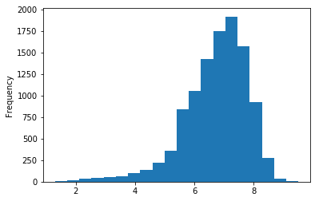

```python
imdb['imdbRating'].plot.hist(alpha=1, bins=20)
```

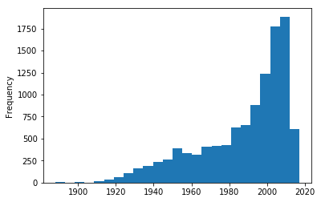

```python
imdb['year'].plot.hist(alpha=1, bins=25)
```

The 'year' distribution shows a steady increase in movie production over the years until when it exploded, beginning around the 1980s, dramatically increasing since then.

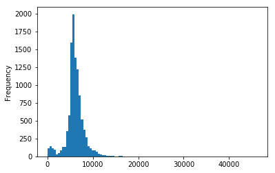

```python
imdb['duration'].plot.hist(alpha=1, bins=100)
```

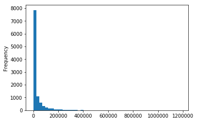

```python
imdb['ratingCount'].plot.hist(alpha=1, bins=50)
```

The 'ratingCount' distribution shows an exponential-logarithmic distribution. Most movies in the database have under 20,000 ratings.

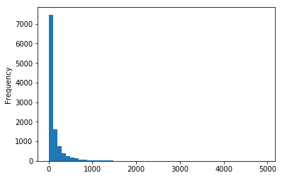

```python
imdb['nrOfUserReviews'].plot.hist(alpha=1, bins=50)
```

The 'nrOfUserReviews' distribution also shows an exponential-logarithmic distribution. Most movies in the database have under 100 reviews. This also suggests that 'ratingCount' and 'nrOfUserReviews' could be closely related.

We will further intestigate the distribution for 'ratingCount' and 'nrOfUserReviews with describe().

```python
imdb['ratingCount'].describe()
```

```
count    1.082100e+04
mean     3.114393e+04
std      7.064455e+04
min      5.000000e+00
25%      1.175000e+03
50%      5.742000e+03
75%      2.787200e+04
max      1.183395e+06
Name: ratingCount, dtype: float64
```

```python
imdb['nrOfUserReviews'].describe()
```

```
count    11072.000000
mean       130.816113
std        256.682991
min          0.000000
25%         13.000000
50%         49.000000
75%        137.000000
max       4928.000000
Name: nrOfUserReviews, dtype: float64
```

Notice that the max of each variable is much further away from even the 75 percentile of each respective variable.

# Bivariate Analysis

We will now perform bivariate analysis for the data. We'll train a linear regression model with Statsmodels for each variable of interest against 'imdbRating' with the hopes of uncovering what effect these variables have on 'imdbRating'.

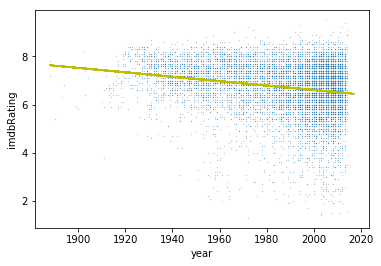

```python
reg = smf.ols(formula='imdbRating ~ year', data=imdb).fit()
b,m = reg.params
x = imdb['year']
imdb.plot.scatter(x='year',y='imdbRating',s=.02)
plt.plot(x,m*x + b,'-',color='y')
```

The scatterplot shows that 'year' has a negative correlation with 'imdbRating'. This means that ratings will be increasingly harsher as the years go on. The opaqueness of the right side of the scatterplot shows a large majority of movies are younger. This corresponds with what we've seen from the histogram for 'year'.

We will now just summary() to on our trained regression model to reveal more information about the distribution. This analysis procedure will be used for all variables of interest.

```python
reg.summary()
```

OLS Regression Results

| Dep. Variable: | imdbRating | R-squared: | 0.040 |
| --- | --- | --- | --- |
| Model: | OLS | Adj. R-squared: | 0.040 |
| Method: | Least Squares | F-statistic: | 448.7 |
| Date: | Sat, 16 Dec 2017 | Prob (F-statistic): | 1.33e-97 |
| Time: | 13:23:00 | Log-Likelihood: | -15966. |
| No. Observations: | 10821 | AIC: | 3.194e+04 |
| Df Residuals: | 10819 | BIC: | 3.195e+04 |
| Df Model: | 1 |  |  |
| Covariance Type: | nonrobust |  |  |

|  | coef | std err | t | P>\|t\| | [0.025 | 0.975] |
| --- | --- | --- | --- | --- | --- | --- |
| Intercept | 24.9600 | 0.861 | 28.988 | 0.000 | 23.272 | 26.648 |
| year | -0.0092 | 0.000 | -21.182 | 0.000 | -0.010 | -0.008 |

| Omnibus: | 2221.041 | Durbin-Watson: | 1.684 |
| --- | --- | --- | --- |
| Prob(Omnibus): | 0.000 | Jarque-Bera (JB): | 5063.900 |
| Skew: | -1.167 | Prob(JB): | 0.00 |
| Kurtosis: | 5.405 | Cond. No. | 1.68e+05 |

The coefficient shows the rate of change of 'imdbRating' over 'year' of -.0092, assuming independence for other variables (which is not very likely!). An R-squared value of .04 shows that the correlation is very weak. This will likely be the case for all individual variable analyses, meaning that Imdb rating cannot be reliably attributed to any one variable.

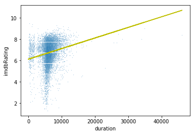

```python
reg = smf.ols(formula='imdbRating ~ duration', data=imdb).fit()
b,m = reg.params
x = imdb['duration']
imdb.plot.scatter(x='duration',y='imdbRating',s=0.02)
plt.plot(x,m*x + b,'-',color='y')
```

The scatter plot shows that 'duration' has a positive correlation with 'imdbRating'. However, even with a scalar as low as 0.02, you can see that distribution of points is still very dense and opaque. This reveals that a vast majority of movies have very similar durations. The nonoutlier grouping of points on the left of the plot is likely due to the data from short films, which we have also seen in the histogram for 'duration'.

```python
reg.summary()
```

OLS Regression Results

| Dep. Variable: | imdbRating | R-squared: | 0.033 |
| --- | --- | --- | --- |
| Model: | OLS | Adj. R-squared: | 0.033 |
| Method: | Least Squares | F-statistic: | 355.9 |
| Date: | Sat, 16 Dec 2017 | Prob (F-statistic): | 4.23e-78 |
| Time: | 13:23:13 | Log-Likelihood: | -15361. |
| No. Observations: | 10463 | AIC: | 3.073e+04 |
| Df Residuals: | 10461 | BIC: | 3.074e+04 |
| Df Model: | 1 |  |  |
| Covariance Type: | nonrobust |  |  |

|  | coef | std err | t | P>\|t\| | [0.025 | 0.975] |
| --- | --- | --- | --- | --- | --- | --- |
| Intercept | 6.1260 | 0.034 | 180.040 | 0.000 | 6.059 | 6.193 |
| duration | 9.937e-05 | 5.27e-06 | 18.866 | 0.000 | 8.9e-05 | 0.000 |

| Omnibus: | 2106.256 | Durbin-Watson: | 1.700 |
| --- | --- | --- | --- |
| Prob(Omnibus): | 0.000 | Jarque-Bera (JB): | 4634.634 |
| Skew: | -1.161 | Prob(JB): | 0.00 |
| Kurtosis: | 5.289 | Cond. No. | 2.14e+04 |

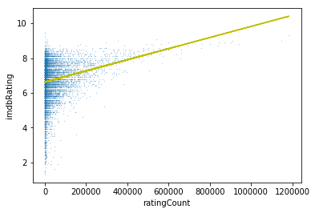

```python
reg = smf.ols(formula='imdbRating ~ ratingCount', data=imdb).fit()
b,m = reg.params
x = imdb['ratingCount']
imdb.plot.scatter(x='ratingCount',y='imdbRating',s=0.02)
plt.plot(x,m*x + b,'-',color='y')
```

The scatter plot shows that 'ratingCount' has a positive correlation with 'imdbRating'. The heavy opaqueness in the area around 0 ratingCount indicates what we have seen in the histogram for 'ratingCount', that a majority of movies have relatively low number of ratings.

```python
reg.summary()
```

OLS Regression Results

| Dep. Variable: | imdbRating | R-squared: | 0.044 |
| --- | --- | --- | --- |
| Model: | OLS | Adj. R-squared: | 0.044 |
| Method: | Least Squares | F-statistic: | 495.6 |
| Date: | Sat, 16 Dec 2017 | Prob (F-statistic): | 2.16e-107 |
| Time: | 13:24:33 | Log-Likelihood: | -15944. |
| No. Observations: | 10821 | AIC: | 3.189e+04 |
| Df Residuals: | 10819 | BIC: | 3.191e+04 |
| Df Model: | 1 |  |  |
| Covariance Type: | nonrobust |  |  |

|  | coef | std err | t | P>\|t\| | [0.025 | 0.975] |
| --- | --- | --- | --- | --- | --- | --- |
| Intercept | 6.6233 | 0.011 | 596.963 | 0.000 | 6.602 | 6.645 |
| ratingCount | 3.199e-06 | 1.44e-07 | 22.262 | 0.000 | 2.92e-06 | 3.48e-06 |

| Omnibus: | 2207.106 | Durbin-Watson: | 1.761 |
| --- | --- | --- | --- |
| Prob(Omnibus): | 0.000 | Jarque-Bera (JB): | 4842.683 |
| Skew: | -1.177 | Prob(JB): | 0.00 |
| Kurtosis: | 5.280 | Cond. No. | 8.44e+04 |

The coefficient shows the rate of change of 'imdbRating' over 'ratingCount' of .000003199, assuming independence for other variables (again, not likely). An R-squared value of .044 shows that the correlation better than the other variables', but is still very weak.

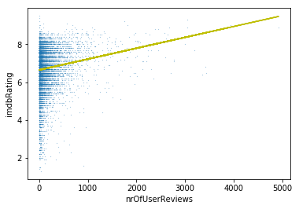

```python
reg = smf.ols(formula='imdbRating ~ nrOfUserReviews', data=imdb).fit()
b,m = reg.params
x = imdb['nrOfUserReviews']
imdb.plot.scatter(x='nrOfUserReviews',y='imdbRating',s=0.02)
plt.plot(x,m*x + b,'-',color='y')
```

The scatter plot shows that 'nrOfUserReviews' has a positive correlation with 'imdbRating'. The shape of the distribution seems very similar to that the previous plot with 'ratingCount'. Similarities between these variables have also been shown in their histogram analyses.

```python
reg.summary()
```

OLS Regression Results

| Dep. Variable: | imdbRating | R-squared: | 0.019 |
| --- | --- | --- | --- |
| Model: | OLS | Adj. R-squared: | 0.019 |
| Method: | Least Squares | F-statistic: | 208.5 |
| Date: | Sat, 16 Dec 2017 | Prob (F-statistic): | 8.12e-47 |
| Time: | 13:26:02 | Log-Likelihood: | -16083. |
| No. Observations: | 10821 | AIC: | 3.217e+04 |
| Df Residuals: | 10819 | BIC: | 3.218e+04 |
| Df Model: | 1 |  |  |
| Covariance Type: | nonrobust |  |  |

|  | coef | std err | t | P>\|t\| | [0.025 | 0.975] |
| --- | --- | --- | --- | --- | --- | --- |
| Intercept | 6.6462 | 0.012 | 574.086 | 0.000 | 6.624 | 6.669 |
| nrOfUserReviews | 0.0006 | 3.97e-05 | 14.438 | 0.000 | 0.000 | 0.001 |

| Omnibus: | 2242.112 | Durbin-Watson: | 1.725 |
| --- | --- | --- | --- |
| Prob(Omnibus): | 0.000 | Jarque-Bera (JB): | 4913.228 |
| Skew: | -1.195 | Prob(JB): | 0.00 |
| Kurtosis: | 5.276 | Cond. No. | 328. |

The coefficient shows the rate of change of 'imdbRating' over 'nrOfUserReviews' of .0006, assuming independence for other variables (again, not likely). An R-squared value of .019 shows that the correlation the worst among the variables of interest, which begs the question if it should even be included in the regression model. We will now perform an analysis on the correlation between 'ratingCount' and 'nrOfUserReviews' to determine this.

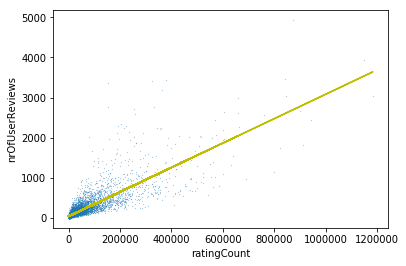

```python
reg = smf.ols(formula='nrOfUserReviews ~ ratingCount', data=imdb).fit()
b,m = reg.params
x = imdb['ratingCount']
imdb.plot.scatter(x='ratingCount',y='nrOfUserReviews',s=0.02)
plt.plot(x,m*x + b,'-',color='y')
```

```python
reg.summary()
```

OLS Regression Results

| Dep. Variable: | nrOfUserReviews | R-squared: | 0.690 |
| --- | --- | --- | --- |
| Model: | OLS | Adj. R-squared: | 0.690 |
| Method: | Least Squares | F-statistic: | 2.413e+04 |
| Date: | Sat, 16 Dec 2017 | Prob (F-statistic): | 0.00 |
| Time: | 13:26:59 | Log-Likelihood: | -69135. |
| No. Observations: | 10821 | AIC: | 1.383e+05 |
| Df Residuals: | 10819 | BIC: | 1.383e+05 |
| Df Model: | 1 |  |  |
| Covariance Type: | nonrobust |  |  |

|  | coef | std err | t | P>\|t\| | [0.025 | 0.975] |
| --- | --- | --- | --- | --- | --- | --- |
| Intercept | 39.0263 | 1.513 | 25.790 | 0.000 | 36.060 | 41.993 |
| ratingCount | 0.0030 | 1.96e-05 | 155.330 | 0.000 | 0.003 | 0.003 |

| Omnibus: | 11574.864 | Durbin-Watson: | 1.716 |
| --- | --- | --- | --- |
| Prob(Omnibus): | 0.000 | Jarque-Bera (JB): | 2407725.240 |
| Skew: | 5.014 | Prob(JB): | 0.00 |
| Kurtosis: | 75.385 | Cond. No. | 8.44e+04 |

```python
reg = smf.ols(formula='imdbRating ~ year + duration + ratingCount', data=imdb).fit()
reg.summary()
```

OLS Regression Results

| Dep. Variable: | imdbRating | R-squared: | 0.132 |
| --- | --- | --- | --- |
| Model: | OLS | Adj. R-squared: | 0.131 |
| Method: | Least Squares | F-statistic: | 528.1 |
| Date: | Sat, 16 Dec 2017 | Prob (F-statistic): | 1.29e-319 |
| Time: | 13:27:36 | Log-Likelihood: | -14798. |
| No. Observations: | 10463 | AIC: | 2.960e+04 |
| Df Residuals: | 10459 | BIC: | 2.963e+04 |
| Df Model: | 3 |  |  |
| Covariance Type: | nonrobust |  |  |

|  | coef | std err | t | P>\|t\| | [0.025 | 0.975] |
| --- | --- | --- | --- | --- | --- | --- |
| Intercept | 30.0874 | 0.842 | 35.732 | 0.000 | 28.437 | 31.738 |
| year | -0.0121 | 0.000 | -28.438 | 0.000 | -0.013 | -0.011 |
| duration | 8.802e-05 | 5.1e-06 | 17.261 | 0.000 | 7.8e-05 | 9.8e-05 |
| ratingCount | 3.508e-06 | 1.42e-07 | 24.791 | 0.000 | 3.23e-06 | 3.79e-06 |

| Omnibus: | 2135.651 | Durbin-Watson: | 1.804 |
| --- | --- | --- | --- |
| Prob(Omnibus): | 0.000 | Jarque-Bera (JB): | 5184.890 |
| Skew: | -1.135 | Prob(JB): | 0.00 |
| Kurtosis: | 5.597 | Cond. No. | 6.80e+06 |

```python
reg = smf.ols(formula='imdbRating ~ year + duration + ratingCount + nrOfUserReviews', data=imdb).fit()
reg.summary()
```

OLS Regression Results

[output not shown]

|  | coef | std err | t | P>\|t\| | [0.025 | 0.975] |
| --- | --- | --- | --- | --- | --- | --- |
| Intercept | 29.8679 | 0.840 | 35.558 | 0.000 | 28.221 | 31.514 |
| year | -0.0120 | 0.000 | -28.241 | 0.000 | -0.013 | -0.011 |
| duration | 9.091e-05 | 5.1e-06 | 17.836 | 0.000 | 8.09e-05 | 0.000 |
| ratingCount | 5.095e-06 | 2.44e-07 | 20.876 | 0.000 | 4.62e-06 | 5.57e-06 |
| nrOfUserReviews | -0.0005 | 6.66e-05 | -7.970 | 0.000 | -0.001 | -0.000 |

| Omnibus: | 2129.037 | Durbin-Watson: | 1.806 |
| --- | --- | --- | --- |
| Prob(Omnibus): | 0.000 | Jarque-Bera (JB): | 5154.758 |
| Skew: | -1.132 | Prob(JB): | 0.00 |
| Kurtosis: | 5.588 | Cond. No. | 6.80e+06 |

```python
reg = smf.ols(formula='imdbRating ~ year + duration + ratingCount + nrOfUserReviews', data=imdb).fit()
reg.summary()
```

OLS Regression Results

| Dep. Variable: | imdbRating | R-squared: | 0.137 |
| --- | --- | --- | --- |
| Model: | OLS | Adj. R-squared: | 0.136 |
| Method: | Least Squares | F-statistic: | 414.4 |
| Date: | Sat, 16 Dec 2017 | Prob (F-statistic): | 0.00 |
| Time: | 13:28:02 | Log-Likelihood: | -14766. |
| No. Observations: | 10463 | AIC: | 2.954e+04 |
| Df Residuals: | 10458 | BIC: | 2.958e+04 |
| Df Model: | 4 |  |  |
| Covariance Type: | nonrobust |  |  |

|  | coef | std err | t | P>\|t\| | [0.025 | 0.975] |
| --- | --- | --- | --- | --- | --- | --- |
| Intercept | 29.8685 | 0.840 | 35.559 | 0.000 | 28.222 | 31.515 |
| year | -0.0120 | 0.000 | -28.242 | 0.000 | -0.013 | -0.011 |
| duration | 9.092e-05 | 5.1e-06 | 17.838 | 0.000 | 8.09e-05 | 0.000 |
| ratingCount | 5.097e-06 | 2.44e-07 | 20.880 | 0.000 | 4.62e-06 | 5.57e-06 |
| nrOfUserReviews | -0.0005 | 6.65e-05 | -7.976 | 0.000 | -0.001 | -0.000 |

| Omnibus: | 2129.051 | Durbin-Watson: | 1.806 |
| --- | --- | --- | --- |
| Prob(Omnibus): | 0.000 | Jarque-Bera (JB): | 5154.692 |
| Skew: | -1.132 | Prob(JB): | 0.00 |
| Kurtosis: | 5.587 | Cond. No. | 6.80e+06 |

While the R-squared for this model is still quite low, it is the best that we can do with the data that we have available for us.

```python
data = {}
data2={}


total=0
counter=0
imdb= imdb[np.isfinite(imdb['imdbRating'])]
for i , row in imdb.iterrows():

    if(row['SciFi']==1):

        if(row['imdbRating']!=np.nan):
            total+=row['imdbRating']
            counter +=1


data ['scifi'] = total/counter
data2['scifi'] = counter

total=0
counter=0

for i , row in imdb.iterrows():
    if(row['Romance']==1):

        if(row['imdbRating']!=np.nan):
            total+=row['imdbRating']
            counter +=1

data ['romance'] = total/counter
data2['romance'] = counter


total=0
counter=0
for i , row in imdb.iterrows():
    if(row['Western']==1):

        if(row['imdbRating']!=np.nan):
            total+=row['imdbRating']
            counter +=1


data['western'] = total/counter
data2['western']= counter





total=0
counter=0

for i , row in imdb.iterrows():
    if(row['Comedy']==1):

        if(row['imdbRating']!=np.nan):
            total+=row['imdbRating']
            counter +=1

data['comedy'] = total/counter
data2['comedy']= counter




total=0
counter=0
for i , row in imdb.iterrows():
    if(row['Drama']==1):

        if(row['imdbRating']!=np.nan):
            total+=row['imdbRating']
            counter +=1


data['drama'] = total/counter
data2['drama']= counter



total=0
counter=0

for i , row in imdb.iterrows():
    if(row['Horror']==1):

        if(row['imdbRating']!=np.nan):
            total+=row['imdbRating']
            counter +=1

data['horror'] = total/counter
data2['horror']= counter



total=0
counter=0
for i , row in imdb.iterrows():
    if(row['Crime']==1):

        if(row['imdbRating']!=np.nan):
            total+=row['imdbRating']
            counter +=1


data['crime'] = total/counter
data2['crime']= counter



total=0
counter=0

for i , row in imdb.iterrows():
    if(row['War']==1):

        if(row['imdbRating']!=np.nan):
            total+=row['imdbRating']
            counter +=1

data['war'] = total/counter
data2['war']= counter



total=0
counter=0
for i , row in imdb.iterrows():
    if(row['Mystery']==1):

        if(row['imdbRating']!=np.nan):
            total+=row['imdbRating']
            counter +=1


data['mystery'] = total/counter
data2['mystery'] =counter



for i , row in imdb.iterrows():
    if(row['Adventure']==1):

        if(row['imdbRating']!=np.nan):
            total+=row['imdbRating']
            counter +=1

data['adventure'] = total/counter
data2['adventure']=counter


total=0
counter=0
for i , row in imdb.iterrows():
    if(row['Animation']==1):

        if(row['imdbRating']!=np.nan):
            total+=row['imdbRating']
            counter +=1


data['animation'] = total/counter
data2['animation']=counter


total=0
counter=0
for i , row in imdb.iterrows():
    if(row['Family']==1):

        if(row['imdbRating']!=np.nan):
            total+=row['imdbRating']
            counter +=1


data['family'] = total/counter
data2['family']=counter


total=0
counter=0
for i , row in imdb.iterrows():
    if(row['Fantasy']==1):

        if(row['imdbRating']!=np.nan):
            total+=row['imdbRating']
            counter +=1


data['fantasy'] = total/counter
data2['fantasy']=counter

total=0
counter=0
for i , row in imdb.iterrows():
    if(row['Thriller']==1):

        if(row['imdbRating']!=np.nan):
            total+=row['imdbRating']
            counter +=1


data['thriller'] = total/counter
data2['thriller']=counter


catagory=[]
average_rate  =[]
count= []

for key,value in  data.items():
    catagory.append(key)
    average_rate.append(value)
    count.append(data2[key])



table = pd.DataFrame({
    "cata": catagory,
    "average_rate": average_rate,
    "number of rate ": count
})


table.sort_values(by='average_rate', ascending=False)
```

|  | average_rate | cata | number of rate |
| --- | --- | --- | --- |
| 7 | 7.266370 | war | 449 |
| 4 | 6.998074 | drama | 5297 |
| 10 | 6.932787 | animation | 549 |
| 1 | 6.846418 | romance | 1773 |
| 6 | 6.789511 | crime | 1678 |
| 2 | 6.764120 | western | 301 |
| 8 | 6.722721 | mystery | 757 |
| 9 | 6.615409 | adventure | 2239 |
| 13 | 6.572288 | thriller | 1263 |
| 3 | 6.532949 | comedy | 3472 |
| 11 | 6.425177 | family | 707 |
| 12 | 6.388984 | fantasy | 699 |
| 0 | 6.083378 | scifi | 740 |
| 5 | 5.963895 | horror | 950 |

We also wonder if the catagory of the movie affect the rating of the movie siginificantly different.

```python
# combine the catagory data into one column

imdb['Cata'] = ""
for i , row in imdb.iterrows():
    if(row['War']==1):
        if(row['Cata']==""):
            imdb.set_value(i,'Cata',"war")
        else:
            row['Cata'] = "war"
            imdb = imdb.append(row)
    if(row['Drama']==1):
        if(len(imdb['Cata'][i])==0):
            imdb.set_value(i,'Cata',"drama")
        else:
            row['Cata'] = "drama"
            imdb = imdb.append(row)
    if(row['Animation']==1):
        if(len(imdb['Cata'][i])==0):
            imdb.set_value(i,'Cata',"animation")
        else:
            row['Cata'] = "animation"
            imdb = imdb.append(row)
    if(row['Romance']==1):
        if(len(imdb['Cata'][i])==0):
            imdb.set_value(i,'Cata',"romance")
        else:
            row['Cata'] = "romance"
            imdb = imdb.append(row)
    if(row['Crime']==1):
        if(len(imdb['Cata'][i])==0):
            imdb.set_value(i,'Cata',"crime")
        else:
            row['Cata'] = "crime"
            imdb = imdb.append(row)
    if(row['Comedy']==1):
        if(len(imdb['Cata'][i])==0):
            imdb.set_value(i,'Cata',"comedy")
        else:
            row['Cata'] = "comedy"
            imdb = imdb.append(row)
```

```python
# drop all movies that are in the other catagory

imdb = imdb[imdb.Cata != ""]
```

As you can see of the graphs, the data points from all different catagory distribute similar to the general movie rating distribution.

However, the points from comedy distribute mainly bottom part of all of the grasphs below. And the data points from war focus around the densest area of the distribution.

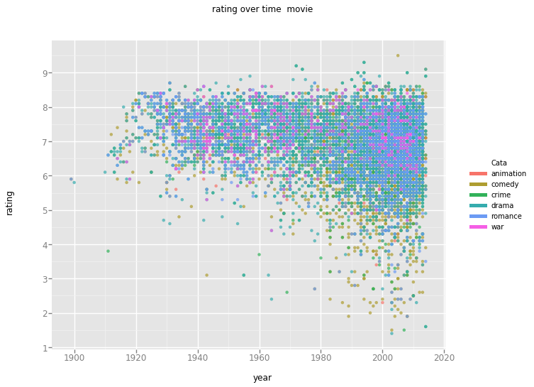

```python
from ggplot import *
ggplot(aes(x='year', y='imdbRating',colour="Cata"), data=imdb) +\
    geom_point(alpha = 0.7) +\
    labs(title="rating over time  movie",
         x = "year",
         y = "rating")
```

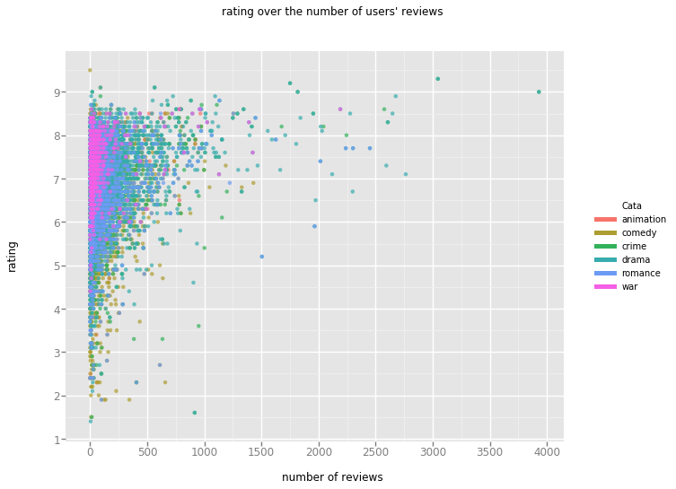

```python
ggplot(aes(x='nrOfUserReviews', y='imdbRating',colour="Cata"), data=imdb) +\
    geom_point(alpha = 0.7) +\
    labs(title="rating over the number of users' reviews",
         x = "number of reviews",
         y = "rating")
```

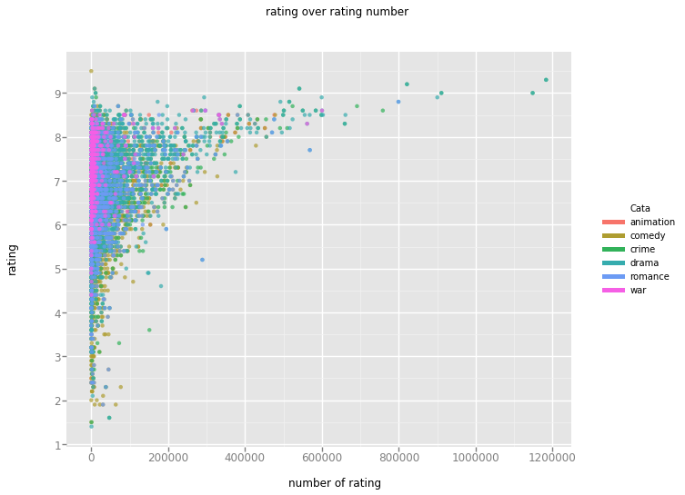

```python
ggplot(aes(x='ratingCount', y='imdbRating',colour="Cata"), data=imdb) +\
    geom_point(alpha = 0.7) +\
    labs(title="rating over rating number",
         x = "number of rating ",
         y = "rating")
```

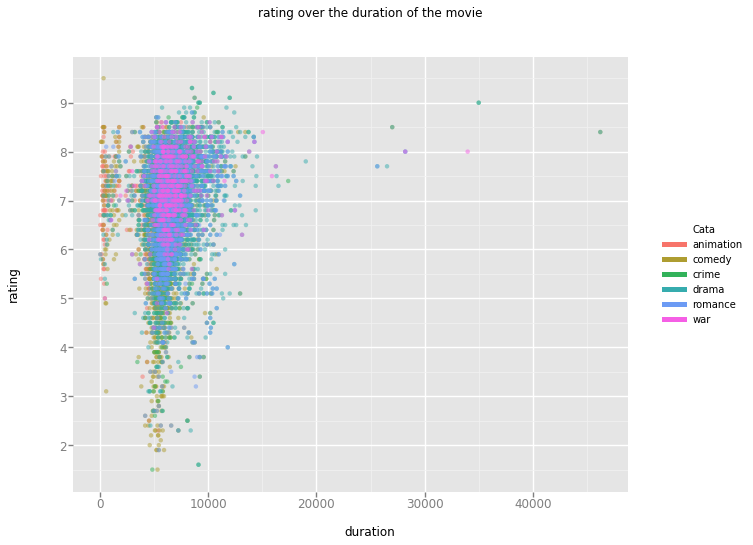

```python
ggplot(aes(x='duration', y='imdbRating',colour="Cata",), data=imdb) +\
    geom_point(alpha = 0.5) +\
    labs(title="rating over the duration of the movie",
         x = "duration",
         y = "rating")
```

Based on all the analysis above, we believe that we can use our genral linear regression model to predict the range the rating of the movie in the category of drama, romance and crime. All the other catagories are bit different then our linear regression model.

Resources we used:

IMDB Movies Dataset with oever 14000 movie data : https://www.kaggle.com/orgesleka/imdbmovies

ggplot: http://ggplot.yhathq.com/

pandas :https://pandas.pydata.org/

numpy : http://www.numpy.org/

matplotlib.pyplot : https://matplotlib.org/api/pyplot_api.html

statsmodels : http://www.statsmodels.org/stable/index.html